# Higher Prelim Topic Revision - Web Version

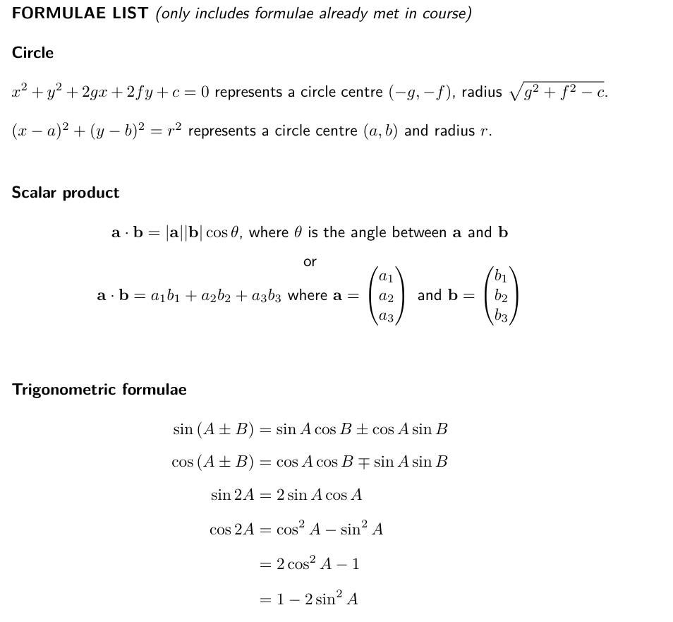

## 1 Straight Line

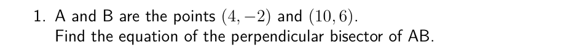

Perpendicular bisectors pass through the *midpoint* of a line segment, and run *perpendicular* to them.

[figure not shown]

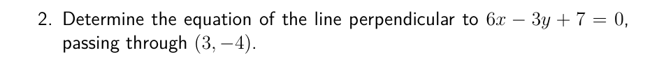

A straight line equation must be rearranged to make $y$ the subject ($y=\dots$) before its gradient can be determined.

$2y=-x-5$ or $y=-\frac{1}{2}x-\frac{5}{2}$

[figure not shown]

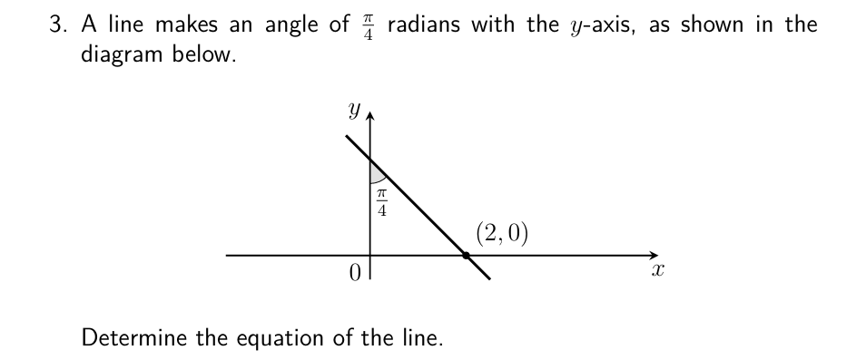

The formula $m=\tan{\theta}$ links a line's gradient to the angle it makes *with the positive direction of the* $x$*-axis*.

[figure not shown]

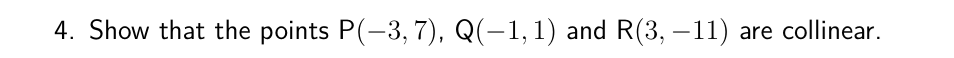

Calculate the gradients of PQ and QR first. The conclusion to a collinearity problem needs to be learned *carefully*.

$m_{PQ}=m_{QR}=-3$, valid statement

[figure not shown]

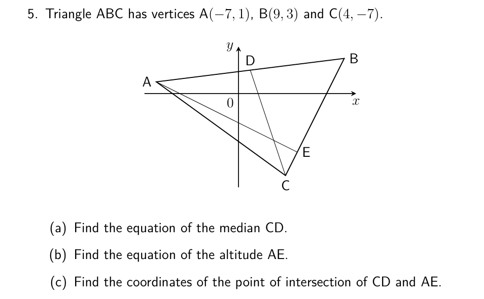

Check the properties of *altitudes* and *medians* of triangles using your notes. Once you have obtained each equation, check that it *matches the diagram* in terms of gradient and $y$-intercept.

[figure not shown]

## 2 Recurrence Relations

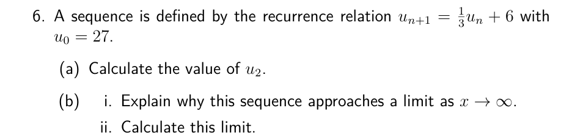

[figure not shown]

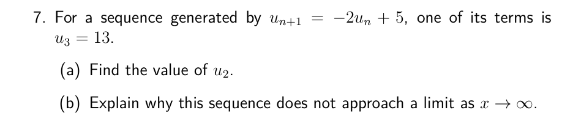

[figure not shown]

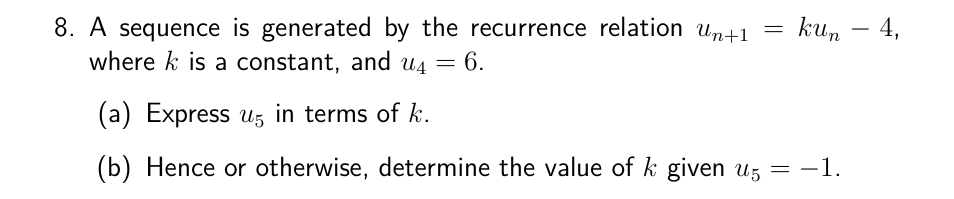

[figure not shown]

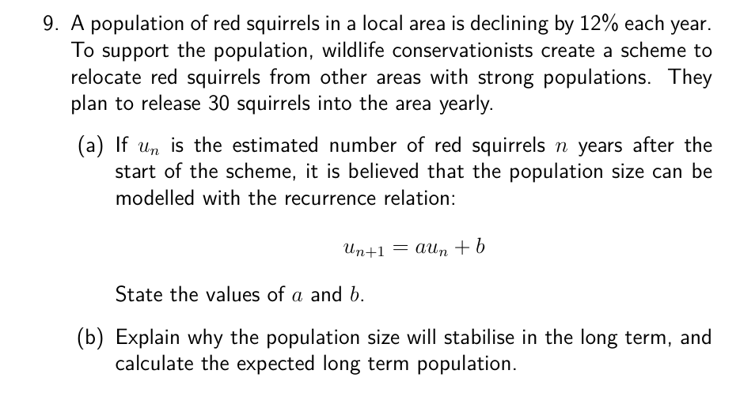

[figure not shown]

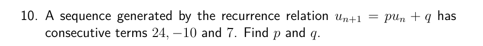

[figure not shown]

## 3 Differentiation I

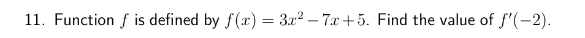

[figure not shown]

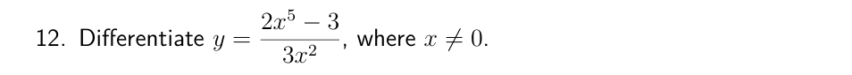

[figure not shown]

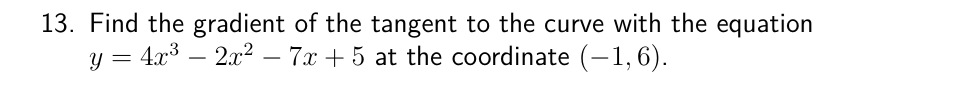

[figure not shown]

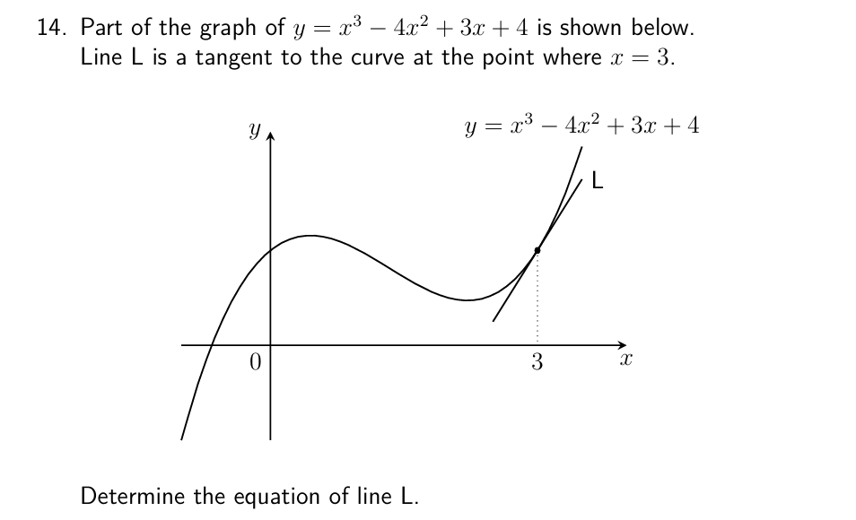

[figure not shown]

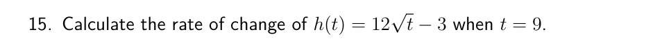

[figure not shown]

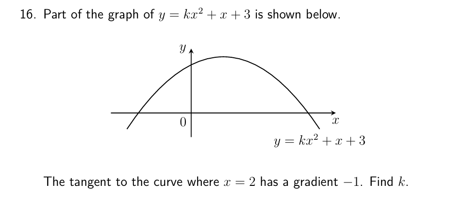

[figure not shown]

## 4 Quadratic Theory

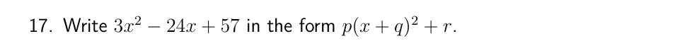

[figure not shown]

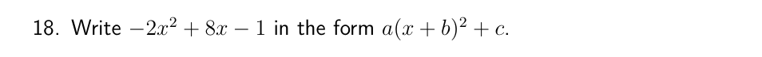

[figure not shown]

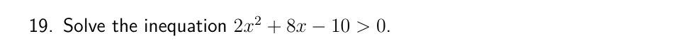

[figure not shown]

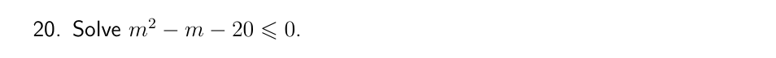

[figure not shown]

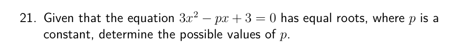

[figure not shown]

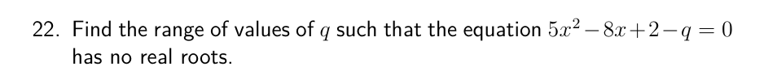

[figure not shown]

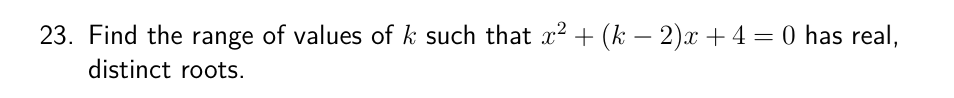

[figure not shown]

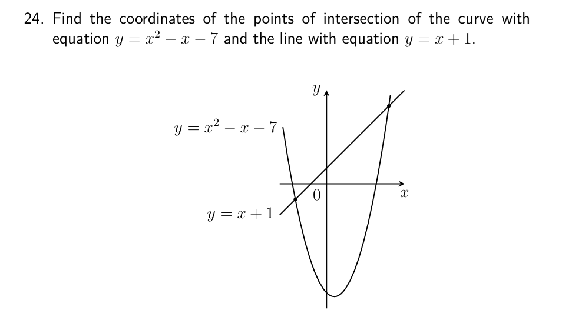

[figure not shown]

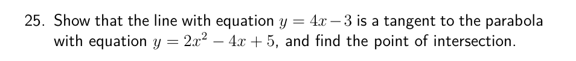

[figure not shown]